# HOMEWORK 02

G01: Betti, D’Arrigo, Masci, Mata Naranjo

# Part 1 - The Bayes Classifier

### Define the Bayes classifier/strategy and briefly explain its role/importance in classification/prediction.

Our usual initial set up for statistical learning is made of data that is random in both response and feature vectors, so the X and Y vectors. We want to use training data to build a predictor, which we can also call strategy since we are in a decision-theoretical framework. There are many such predictors, one of which is the Bayes strategy, which aims at minimizing the risk (and so the expected loss) according to the following formula:
$$\begin{equation} s_{opt}(x) = argminR(s|x) \end{equation}$$
This way, rather than working out the multivariate risk function R(s) we can work one by one in the pointwise-risk and then put all of those together. In particular, the Bayes Classifier corresponds to this strategy applied to the classification task, for which we have a regression function $f_{opt}(x)=\mathbb{P}(Y=1|X=x)$ since $Y \in \{0, 1\}$. As a result, the Bayes Classifier is:
$$\begin{equation} h_{opt}(x) = \mathbb{I}(f_{opt}(x) \ge \frac{1}{2}) \end{equation}$$

### Find (with pen and paper) the Bayes classification rule $h_{opt}(x)$.

It can be proven that under the following conditions:

$$\begin{equation}
Y \in \{0, 1\}
\end{equation}$$

$$\begin{equation}
X \in \mathbb{R}
\end{equation}$$

the optimal classifier is:

$$\begin{equation}
h_{opt}(x) = \mathbb{I}(f_{opt}(x) - 1/2 \geq 0)
\end{equation}$$

In order to estimate the optimal Bayes classification rule we have to derive $f_{opt}(x)$ by using the Bayes Rule:

$$\begin{equation}
\begin{split}
f_{opt}(x)
&= \mathbb{E}(Y=1|X=x) = \mathbb{P}(Y=1|X=x) = \\
&= \frac{\mathbb{P}(X|Y=1)\mathbb{P}(Y=1)}{\mathbb{P}(X|Y=1)\mathbb{P}(Y=1)+\mathbb{P}(X|Y=0)\mathbb{P}(Y=0)} = \\
&\stackrel{i}{=} \frac{\mathbb{P}(X|Y=1)}{\mathbb{P}(X|Y=1)+\mathbb{P}(X|Y=0)} = \\
&\stackrel{ii}{=} \frac{\mathbb{I}_{[-1, 3]}(x)}{\mathbb{I}_{[-1, 3]}(x)+\mathbb{I}_{[-3, 1]}(x)}
\end{split}
\end{equation}$$

where we have used that (i) $P(Y=0) = P(Y=1)$ and (ii) $(X|Y=0) \sim Unif(-3, 1)$ and $(X|Y=1) \sim Unif(-1, 3)$. So finally we have that:

$$\begin{equation}
h_{opt}(x) = \mathbb{I}\bigg(\frac{\mathbb{I}_{[-1, 3]}(x)}{\mathbb{I}_{[-1, 3]}(x)+\mathbb{I}_{[-3, 1]}(x)} - \frac{1}{2} \geq 0\bigg)
\end{equation}$$

### Simulate n = 250 data from the joint data model p(y, x) = p(x | y) · p(y) described above, and then:

#### a. Plot the data together with the regression function that defines $h_{opt}(x)$

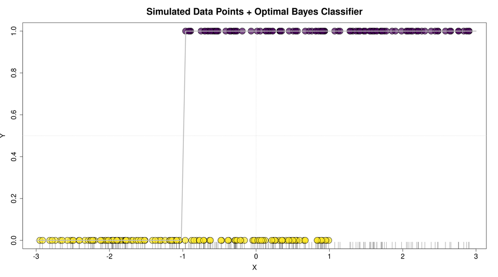

```r
# Generate Random Data
n <- 250
y <- sample(c(0,1), size=n, replace=TRUE, prob=c(.5,.5))
x_given_y <- c()
for (yi in y){
  if (yi==0){
    x <- runif(1, -3, 1)
  } else {
    x <- runif(1, -1, 3)
  }
  x_given_y <- c(x_given_y, x)
}

# Optimal Bayes Classifier
h.opt <- function(x) {

  f.opt = (ifelse((x<=3&x>=-1), 1, 0))/(ifelse((x<=3&x>=-1), 1, 0) + ifelse((x<=1&x>=-3), 1, 0))
  res = ifelse(f.opt-.5>=0, 1, 0)
  return(res)
}

# Plot + Regression Function
mycol = viridis(7, alpha = .7)
plot(x = x_given_y, y = y, bg= ifelse(y == 1, mycol[1], mycol[7]),
     pch=21, xlab="X", ylab = "Y", main="Simulated Data Points + Optimal Bayes Classifier", cex=3,
     cex.lab=1.5, cex.axis=1.5, cex.main=2)
abline(h = 0.5, lty = 3, col = gray(.8))
abline(v = 0, lty = 3, col = gray(.8))
rug(x_given_y)
curve(h.opt(x), from=-3, to=3, add = TRUE, col="gray", lwd=3)
```

#### b. Evaluate the performance of the Bayes Classifiers on these simple (only 1 feature!) data

The performance evaluation will be done using the binary loss function (which is the loss function used to derived the $h_{opt}()x$ function used to construct this Bayes Classifier):

```r
# Loss Function
loss <- function(y.actual, y.pred) {

  res = sum(y.actual != y.pred)
  return(res)
}

print(paste("Bayes Classifier Loss:", loss(y, h.opt(x_given_y))))
```

```
## [1] "Bayes Classifier Loss: 62"
```

```r
print(paste("Relative Bayes Classifier Loss:", loss(y, h.opt(x_given_y))/length(y)))
```

```
## [1] "Relative Bayes Classifier Loss: 0.248"
```

#### c. Apply any other classifier of your choice to these data and comparatively comment its performance

In this section we will choose another Classifier to compare its performance against that of the Bayes Classifier. The most obvious option at this point seems to be the Logistic Regression, so we will give this Classifier a try:

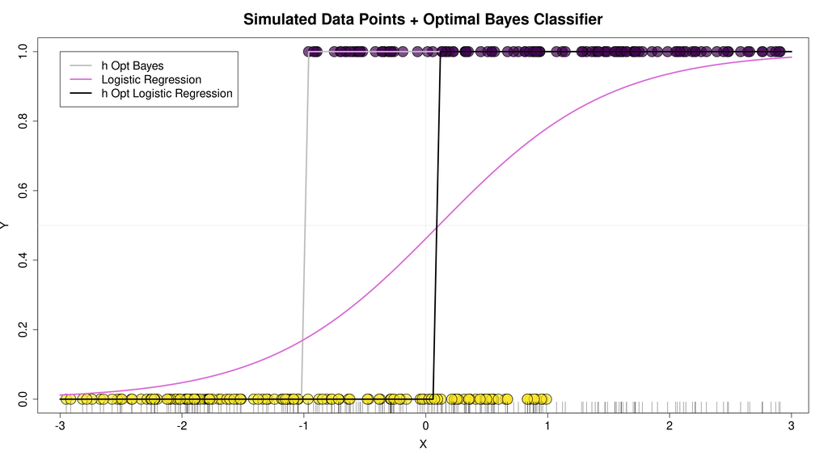

```r
logistic_regression <- function(x, y) {

  data = data.frame(y, x)
  fit_logit <- glm(y ~ ., data = data, family = "binomial")
  params = coef(fit_logit)
  return(params)
}

logit_func <- function(x, parameters=params) 1/(1 + exp(-(parameters[1]+parameters[2]*x)))

params = logistic_regression(x=x_given_y, y=y)

# Plot + Regression Function
plot(x = x_given_y, y = y, bg= ifelse(y == 1, mycol[1], mycol[7]),
     pch=21, xlab="X", ylab = "Y", main="Simulated Data Points + Optimal Bayes Classifier", cex=3,
     cex.lab=1.5, cex.axis=1.5, cex.main=2)
abline(h = 0.5, lty = 3, col = gray(.8))
abline(v = 0, lty = 3, col = gray(.8))
rug(x_given_y)
curve(h.opt(x), from=-3, to=3, add = TRUE, col="gray", lwd=3)
curve(logit_func(x, parameters=params), from=-3, to=3, add = TRUE, col="orchid", lwd=3)
curve(round(logit_func(x, parameters=params)), from=-3, to=3, add = TRUE, col="black", lwd=3)
legend(x=-3,, y=1,
       legend=c("h Opt Bayes", "Logistic Regression", "h Opt Logistic Regression"),
       #legend=c("1", "2", "3"),
       col=c("gray", "orchid", "black"), cex=1.5, lty=1, lwd=3)
```

```r
print(paste("Logistic Regression Classifier Loss:", loss(y, round(logit_func(x=x_given_y, parameters=params)))))
```

```
## [1] "Logistic Regression Classifier Loss: 63"
```

```r
print(paste("Relative Logistic Regression Classifier Loss:", loss(y, round(logit_func(x=x_given_y, parameters=params)))/length(y)))
```

```
## [1] "Relative Logistic Regression Classifier Loss: 0.252"
```

#### d. Who’s the best after 1000 simulations?

In order to compare both classifiers we will perform 1000 simulations and estimate the loss for each of the random samples.

```r
M = 1000
res_bayes = rep(NA, M)
res_log = rep(NA, M)

for(sim in 1:M){

  #if(sim%%10 == 0){
  #  print(sim)
  #}
  # Simulate Random Data
  n <- 250
  y <- sample(c(0,1), size=n, replace=TRUE, prob=c(.5,.5))
  x_given_y <- c()
  for (yi in y){
    if (yi==0){
      x <- runif(1, -3, 1)
    } else {
      x <- runif(1, -1, 3)
    }
    x_given_y <- c(x_given_y, x)
  }

  # Make predictions with Logistic Regression
  params = logistic_regression(x=x_given_y, y=y)
  res_log[sim] = loss(y, round(logit_func(x=x_given_y, parameters=params)))

  # Make predictions with Bayes
  res_bayes[sim] = loss(y, h.opt(x_given_y))

}

print(paste("Average Bayes Classifier Loss:", mean(res_bayes)))
```

```
## [1] "Average Bayes Classifier Loss: 62.364"
```

```r
print(paste("Average Logistic Regression Classifier Loss:", mean(res_log)))
```

```
## [1] "Average Logistic Regression Classifier Loss: 61.619"
```

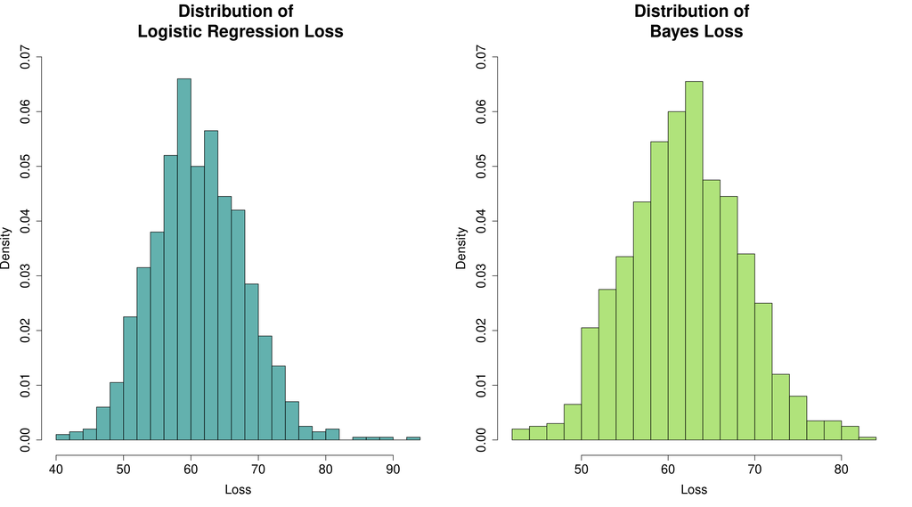

```r
par(mfrow = c(1:2))
hist(res_log, prob=TRUE, main="Distribution of \n Logistic Regression Loss", xlab="Loss", col=mycol[4], ylim = c(0, 0.07), breaks=20, cex.lab=1.5, cex.axis=1.5, cex.main=2)
hist(res_bayes, prob=TRUE, main="Distribution of \n Bayes Loss", xlab="Loss", col=mycol[6], ylim = c(0, 0.07), breaks=20, cex.lab=1.5, cex.axis=1.5, cex.main=2)
```

The previous plots show the distribution of number of miss-classified data points over 1000 simulations. We see how in both cases the distribution has a Gaussian-like shape. However, repeating this process multiple times we have observed that the Bayes Classifier gives a more stable loss distribution, while the Logistic Regression leads to some more skewed and with higher variance distributions.

The Logistic Regression Classifier outperforms the Bayes classifier, however, not by much. The reason for which Logistic Regression is able to classify better is due to the fact that it classifies data points dynamically in the interval $x \in [-1, 1]$, while the Bayes Classifier will always assign these points to the class $Y=1$. Theoretically, the Bayes approach should be the ideal classifier (since the data points are equally distributed among $Y=1$ and $Y=0$ in this interval), however since our data generating process only generates 250 points, the real distribution in the $[-1, 1]$ interval is not exactly equally distributed.

# Part 2 - Gradient descent algorithm

## Implementation of the gradient descent algorithm for the linear regression classifier

In the following, the implementation of the gradient descent is provided. Let’s recall that the linear regression classifier is such that

$$\begin{equation}
h(\mathbf{x}) = \mathbb{I}\Big(f(\mathbf{x}) \geq \frac{1}{2}\Big)
\end{equation}$$

where $f(\mathbf{x}) = \arg_{f\in\mathcal{F}}\min \hat{R}(f) = \mathbf{x}^T\mathbf{\beta} + x_0\beta_0$, $x_0=1$. From now on, we assume that the design matrix $\mathbb{X}$ contains also $x_0$ and hence $\mathbf{\beta} \leftarrow [\mathbf{\beta}, \beta_0]^T$. Then, the gradient is equal to

$$\begin{equation}
\nabla \hat{R}(\mathbf{\beta}) = \nabla \Bigg(\frac{1}{n} \Vert (\mathbf{Y} - \mathbb{X}\mathbf{\beta} \Vert_2^2\Bigg) = \mathbb{X}^T \mathbb{X}\mathbf{\beta} - \mathbb{X}^T \mathbf{Y}
\end{equation}$$

Finally, the update rule of the gradient descent algorithm is

$$\begin{equation}
\mathbf{\beta} \leftarrow \mathbf{\beta} - \alpha \nabla \hat{R}(\mathbf{\beta})
\end{equation}$$

```r
# Define the regression function
f_reg <- function(X, beta) cbind(1,X) %*% beta


# Define the linear classifier
linear_classifier <- function(X, beta) ifelse(f_reg(X, beta) >= 0.5, 1, 0)


# Define the gradient for the linear
gradient_linear <- function(X.T_X, X.T_Y, beta) X.T_X %*% beta - X.T_Y


# Define the empirical risk
empirical_risk <- function(y.pred.reg, y.true) mean((y.pred.reg-y.true)^2) # OLS


# Define the gradient descent function
gradient_descent <- function(X, Y, G, alpha=0.5, max_iter=100, tol=0.000001, beta=NULL, plot=FALSE, verbose=95) {
  ###
  # Function to compute the gradient descent given the gradient function G.
  # :param X : design matrix (n_observations * n_features)
  # :param Y : ground-truth labels
  # :param G : gradient function
  # :param alpha : learning rate
  # :param max_iter : maximum number of iterations; first stop condition
  # :param tol : tolerance; stop the gradient loop before max_iter is reached if the condition is met
  # :param beta : vector of parameters; provide a custom starting vector; otherwise, a random one is chosen
  # :param plot : boolean; plot the empirical risk history if TRUE
  # :param verbose : level of verbosity; if 0, only starting and ending are notified;
  #                   if > 0, the higher the value, the more verbose the function; if > 99, a message is printed
  #                   after 100 iterations
  #
  # :return list(beta=[vector of parameters], emp_risk_hist=[empirical risk through the iterations])
  ###
  t_0 <- Sys.time(); print(t_0)

  verbose = ifelse(verbose > 99, 100, 100 - verbose)

  notify <- ifelse(verbose > 0, function(i, ER) {
    if((i %% verbose) == 0) print(paste("Iteration", i, " ER:", ER))
  }, function(i, ER) {})

  n <- dim(X)[1] # number of observations (data points)
  d <- dim(X)[2] # number of features

  if(is.null(beta))
    beta <- matrix(rep(0,d+1))

  emp_risk_hist <- rep(0, max_iter+1)

  print("Precomputing the matrices")

  X.T_X <- crossprod(cbind(1,X)) * (2 / n) # (d+1) x (d+1); equivalent to t(X)%*%X but faster
  X.T_Y <- crossprod(cbind(1,X), Y) * (2 / n) # (d+1) x 1;

  print("Entering gradient loop...")

  # Gradient loop
  for(i in 1:max_iter) {

    grad <- G(X.T_X, X.T_Y, beta)

    # Update beta
    beta <- beta - alpha * grad # update rule

    # Compute and store the ER value of the i-th iteration
    emp_risk_hist[i+1] <- empirical_risk(f_reg(X, beta), Y)

    notify(i, emp_risk_hist[i+1])

    # Check convergence
    if(abs(emp_risk_hist[i]-emp_risk_hist[i+1]) <= tol) {
      max_iter <- i
      break
    }

  }

  print(paste("Converged after", max_iter, "iterations", "|", "ER:", emp_risk_hist[max_iter+1]))

  print(Sys.time() - t_0)

  if(plot)
    plot(seq(1,max_iter), emp_risk_hist[2:(max_iter+1)], col="blue",
         xlab="iter", ylab="ER", main="Gradient descent")

  return(list(param=beta, emp_risk_hist=emp_risk_hist[-1]))
}
```

Before training the classifier on the Amazon reviews data set, let’s see how the classifier behaves, borrowing the data set generated in the previous exercise:

```
## [1] "2021-05-31 18:38:07 CEST"
## [1] "Precomputing the matrices"
## [1] "Entering gradient loop..."
## [1] "Converged after 67 iterations | ER: 0.12317956563485"
## Time difference of 0.008668661 secs
```

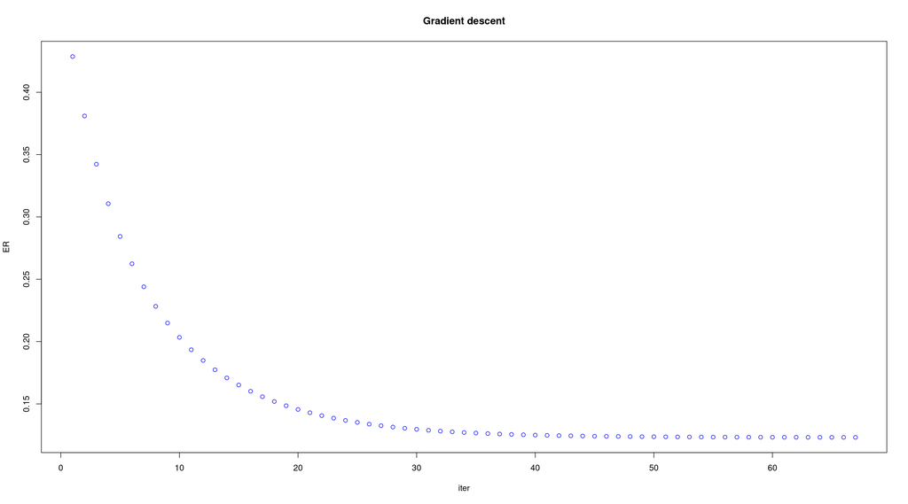

```r
x_given_y <- matrix(x_given_y)

result.test <- gradient_descent(x_given_y, y, gradient_linear, alpha=0.03, max_iter=500, tol=0.00001, plot=T, verbose=1)
```

After the training, the results are visualized in the plot below:

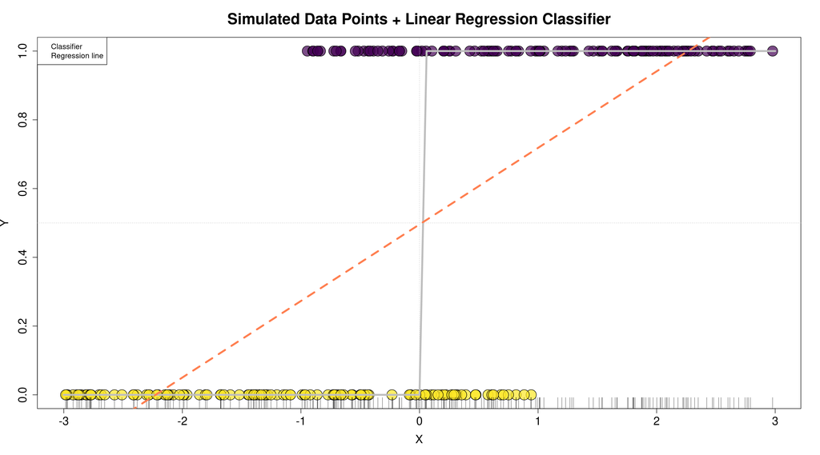

## Train the model on the Amazon reviews data set

Load the Amazon reviews data set:

```r
load("../data/amazon_review_clean.RData")
```

The design matrix $\mathbb{X}$ contains the TF-IDF scores for each word (feature) in each review. Specifically, it has a (149992, 1334) size.

Because among the features there are also some that seem to be not so relevant - such as articles, prepositions and punctuation - the words that are recognized to be stop words have been removed.

```
##     one book movie like story good great just read time
## 1  0.00 1.37     0 0.00     0    0     0 0.00 0.00 0.00
## 6  0.00 0.00     0 1.76     0    0     0 0.00 0.00 2.02
## 7  0.00 0.00     0 0.00     0    0     0 0.00 1.92 0.00
## 8  0.00 0.00     0 0.00     0    0     0 0.00 0.00 0.00
## 10 0.00 0.00     0 0.00     0    0     0 0.00 0.00 0.00
## 12 1.26 1.37     0 0.00     0    0     0 0.00 1.92 2.02
## 14 0.00 4.11     0 0.00     0    0     0 1.91 1.92 0.00
## 15 1.26 4.11     0 1.76     0    0     0 1.91 3.83 0.00
## 16 1.26 0.00     0 0.00     0    0     0 3.82 1.92 0.00
## 18 1.26 0.00     0 1.76     0    0     0 1.91 1.92 0.00
```

Since we know that $\mathbb{X}^T \mathbb{X}$ may be unstable, we will also check that we don’t have any correlated features (excluding auto-correlation).

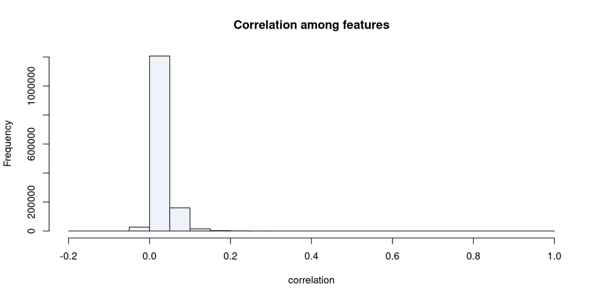

```r
correlation = cor(X_tr)
diag(correlation) <- 0
hist(correlation, main = 'Correlation among features', col='#edf2fb', ylab = 'Frequency')
```

At this stage, it is worth to point out that such classifier induces some further considerations. Indeed, differently from the logistic regression classifier, the linear regression classifier doesn’t explicitly map the values of the regression function into $[0,1]$, whatever great they are; hence, when computing the gradient, the initialization of the the parameters $\mathbf{\beta}$ and the learning rate $\alpha$ play an even more crucial role: $\alpha$ must balance the potentially huge contribute of the gradient $\mathbb{X}^T \mathbb{X}\mathbf{\beta} - \mathbb{X}^T \mathbf{Y}$, which for such a high-sized matrix $\mathbb{X}$ with positive values greater than 1 and for $\mathbf{\beta} \neq [0,0,...,0]^T$ may diverge or incur in numeric overflows. For this reasoning, initially the maximum value of $\alpha$ for which the algorithm converges was found to be 0.001.

But, such a small learning rate causes the algorithm to converge after many iterations: in the trials, almost 4000 iterations were required to reach the convergence with a good (small) approximation tolerance.

Even though train the model on this data set for such many iterations is not prohibitive - the training takes just about 15 minutes -, to speed up the convergence and improve the stability and the final performance of the model, a normalization step $x_i^{(j)} = \frac{x^{(j)}_i - \min{x^{(j)}}}{\max{x^{(j)}} - \min{x^{(j)}}}$ to map all the features values in the interval $[0,1]$ is performed before training; this interval allows to keep $\mathbb{X}$ sparse, making the optimization about which we will further discuss still possible:

```r
X_tr = apply(X_tr,2,function(x){x/max(x)})
X_te = apply(X_te,2,function(x){x/max(x)})
```

It may be noticed that such design matrix, even if apparently huge, is extremely sparse. In order to compress it, saving space and speeding the computations, the original matrices have been converted into `sparseMatrix` objects of the `Matrix` library. It can be shown that, relying on this library, the gain of the performance in terms of the computation speed is really remarkable:

```r
X_tr <- as(X_tr, "sparseMatrix")
X_te <- as(X_te, "sparseMatrix")
```

Looking at the environment variables, it is impressive to notice that the design matrix, through this optimization, no longer takes about 1.6GB but just about 120MB.

As a final step before going through the actual training of the model, the $\mathbf{Y}$ labels are mapped to $\{0, 1\}$.

```r
encode <- function(Y) {
  unique_labs <- unique(Y)
  Y_encoded <- as.integer(Y == unique_labs[2])
  return(matrix(Y_encoded))
}

y_tr_encoded <- encode(y_tr)
```

Finally, the model is trained:

```
## [1] "2021-05-31 18:47:28 CEST"
## [1] "Precomputing the matrices"
## [1] "Entering gradient loop..."
## [1] "Iteration 100  ER: 0.168213379263587"
## [1] "Iteration 200  ER: 0.140437108603211"
## [1] "Iteration 300  ER: 0.130220265394437"
## [1] "Iteration 400  ER: 0.125887835438233"
## [1] "Iteration 500  ER: 0.123651411075671"
## [1] "Iteration 600  ER: 0.122247926181081"
## [1] "Iteration 700  ER: 0.121233689409478"
## [1] "Iteration 800  ER: 0.120437763075775"
## [1] "Iteration 900  ER: 0.119784473599932"
## [1] "Iteration 1000  ER: 0.119234307420152"
## [1] "Converged after 1000 iterations | ER: 0.119234307420152"
## Time difference of 1.251581 mins
```

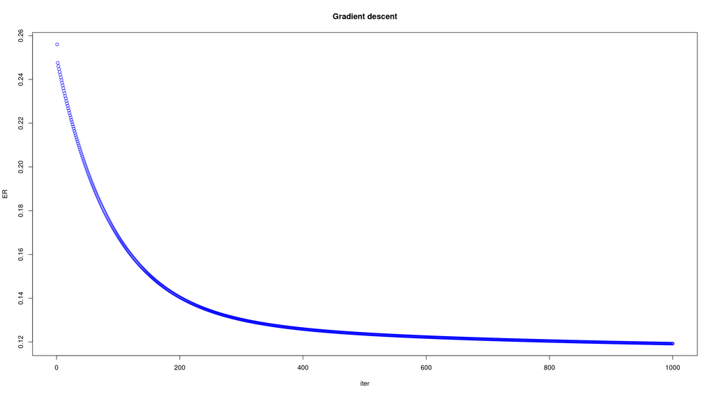

```r
result <- gradient_descent(X_tr, y_tr_encoded, gradient_linear, alpha=0.4, max_iter=1000, plot=T, verbose=100)
```

Evaluating the model on the test set, the accuracy after training is:

```r
y_te_encoded <- encode(y_te)

pred <- linear_classifier(X_te, result$param)

accuracy <- sum(pred == y_te_encoded) / length(y_te_encoded)

print(paste("Accuracy of the model:", accuracy))
```

```
## [1] "Accuracy of the model: 0.949075926074086"
```

### Stochastic Implementation

The stochastic version of the gradient descent may be implemented in many different ways, which may be more or less suitable depending on the data set. In the *mini-batch* version we compute the gradient using a subset of *m* randomly selected observations at each iteration, while in the more “extreme” case of the *online* stochastic GD, at each iteration we estimate the gradient and update $\beta$ for a single observation. Lastly, there’s a “hybrid” version of the stochastic GD for which $\beta$ is updated based on a single observation but at each iteration, called *epoch*, we actually consider a mini-batch of *m* observations to compute the ER and update the learning rate to $\alpha/t$, where *t* is the epoch. Below we provide the code for each of the three approaches.

```r
GD_stochastic_online <- function(X, Y, alpha=0.5, max_iter=100, tol=0.001, beta=NULL, plot=FALSE, verbose=95) {
  ###
  # Function to compute the gradient descent given the gradient function G.
  # :param X : design matrix (n_observations * n_features)
  # :param Y : ground-truth labels
  # :param G : gradient function
  # :param alpha : learning rate
  # :param max_iter : maximum number of iterations; first stop condition
  # :param tol : tolerance; stop the gradient loop before max_iter is reached if the condition is met
  # :param beta : vector of parameters; provide a custom starting vector; otherwise, a random one is chosen
  # :param plot : boolean; plot the empirical risk history if TRUE
  # :param verbose : level of verbosity; if 0, only starting and ending are notified;
  #                   if > 0, the higher the value, the more verbose the function; if > 99, a message is printed
  #                   after 100 iterations
  #
  # :return list(beta=[vector of parameters], emp_risk_hist=[empirical risk through the iterations])
  ###

  t_0 <- Sys.time(); print(t_0)

  verbose = ifelse(verbose > 99, 100, 100 - verbose)

  notify <- ifelse(verbose > 0, function(i, ER) {
  if((i %% verbose) == 0) print(paste("Iteration", i, " ER:", ER))
  }, function(i, ER) {})

  n <- dim(X)[1] # number of observations (data points)
  d <- dim(X)[2] # number of features

  if(is.null(beta))
    beta <- matrix(c(10,rep(0,d)))

  emp_risk_hist <- rep(0, max_iter+1)

  print("Entering gradient loop...")

  # Gradient loop
  for(i in 1:max_iter) {

    #sampling one data point
    idx <- sample(seq(1, n), size = 1, replace = FALSE)

    X.T_X <- tcrossprod(cbind(1,matrix(X[idx,], nrow=1))) * 2
    X.T_Y <- cbind(1,matrix(X[idx,], nrow=1)) * Y[idx] * 2
    grad <- X.T_X[1] * beta - X.T_Y[1]

    # update alpha
    alpha_adj = alpha/i

    # Update beta
    beta <- beta - alpha_adj * grad

    # Compute and store the ER value of the i-th iteration
    emp_risk_hist[i+1] <- empirical_risk(f_reg(matrix(X[idx,], nrow=1), beta), Y[idx,])

    notify(i, emp_risk_hist[i+1])

    # Check convergence
   if(abs(emp_risk_hist[i]-emp_risk_hist[i+1]) <= tol) {
      max_iter <- i
      break
    }

  }

  print(paste("Converged after", max_iter, "iterations", "|", "ER:", emp_risk_hist[max_iter+1]))

  print(Sys.time() - t_0)

  if(plot)
    plot(seq(1,max_iter), emp_risk_hist[2:(max_iter+1)],
         xlab="iter", ylab="ER", main="Gradient descent",
         lty = 1, type='s', col = "coral")

  return(list(param=beta, emp_risk_hist=emp_risk_hist[-1]))
}
```

```r
GD_stochastic_mb <- function(X, Y, G, alpha=0.5, max_iter=100, m=500, tol=0.001, beta=NULL, plot=FALSE, verbose=95) {
  ###
  # Function to compute the gradient descent given the gradient function G.
  # :param X : design matrix (n_observations * n_features)
  # :param Y : ground-truth labels
  # :param G : gradient function
  # :param alpha : learning rate
  # :param max_iter : maximum number of iterations; first stop condition
  # :param m : batch size
  # :param tol : tolerance; stop the gradient loop before max_iter is reached if the condition is met
  # :param beta : vector of parameters; provide a custom starting vector; otherwise, a random one is chosen
  # :param plot : boolean; plot the empirical risk history if TRUE
  # :param verbose : level of verbosity; if 0, only starting and ending are notified;
  #                   if > 0, the higher the value, the more verbose the function; if > 99, a message is printed
  #                   after 100 iterations
  #
  # :return list(beta=[vector of parameters], emp_risk_hist=[empirical risk through the iterations])
  ###

  t_0 <- Sys.time(); print(t_0)

  verbose = ifelse(verbose > 99, 100, 100 - verbose)

  notify <- ifelse(verbose > 0, function(i, ER) {
  if((i %% verbose) == 0) print(paste("Iteration", i, " ER:", ER))
  }, function(i, ER) {})

  n <- dim(X)[1] # number of observations (data points)
  d <- dim(X)[2] # number of features

  if(is.null(beta))
  beta <- matrix(c(10,rep(0,d)))

  emp_risk_hist <- rep(0, max_iter+1)

  print("Entering gradient loop...")


  # Gradient loop
  for(i in 1:max_iter) {

    #sampling one data point
    idx <- sample(seq(1, n), size = m, replace = FALSE)

    # Update alpha
    alpha_adj = alpha/i

    X.T_X <- crossprod(cbind(1,X[idx,])) * (2 / m)
    X.T_Y <- crossprod(cbind(1,X[idx,]), Y[idx]) * (2 / m)

    grad <- G(X.T_X, X.T_Y, beta)
    # Update beta
    beta <- beta - alpha_adj * grad

    # Compute and store the ER value of the i-th iteration
    emp_risk_hist[i+1] <- empirical_risk(f_reg(X[idx,], beta), Y[idx,])

    notify(i, emp_risk_hist[i+1])

    # Check convergence
   if(abs(emp_risk_hist[i]-emp_risk_hist[i+1]) <= tol) {
      max_iter <- i
      break
    }

  }

  print(paste("Converged after", max_iter, "iterations", "|", "ER:", emp_risk_hist[max_iter]))

  print(Sys.time() - t_0)

  if(plot)
    plot(seq(1,max_iter), emp_risk_hist[2:(max_iter+1)],
         xlab="iter", ylab="ER", main="Gradient descent",
         lty = 1, type='s', col = "coral")

  return(list(param=beta, emp_risk_hist=emp_risk_hist[-1]))
}
```

```r
GD_stochastic_hybrid <- function(X, Y, alpha=0.5, max_iter=100, m=500, tol=0.001, beta=NULL, plot=FALSE, verbose=95) {
  ###
  # Function to compute the gradient descent given the gradient function G.
  # :param X : design matrix (n_observations * n_features)
  # :param Y : ground-truth labels
  # :param G : gradient function
  # :param alpha : learning rate
  # :param max_iter : maximum number of iterations; first stop condition
  # :param m : batch size
  # :param tol : tolerance; stop the gradient loop before max_iter is reached if the condition is met
  # :param beta : vector of parameters; provide a custom starting vector; otherwise, a random one is chosen
  # :param plot : boolean; plot the empirical risk history if TRUE
  # :param verbose : level of verbosity; if 0, only starting and ending are notified;
  #                   if > 0, the higher the value, the more verbose the function; if > 99, a message is printed
  #                   after 100 iterations
  #
  # :return list(beta=[vector of parameters], emp_risk_hist=[empirical risk through the iterations])
  ###

  t_0 <- Sys.time(); print(t_0)

  verbose = ifelse(verbose > 99, 100, 100 - verbose)

  notify <- ifelse(verbose > 0, function(i, ER) {
  if((i %% verbose) == 0) print(paste("Iteration", i, " ER:", ER))
  }, function(i, ER) {})

  n <- dim(X)[1] # number of observations (data points)
  d <- dim(X)[2] # number of features

  if(is.null(beta))
  beta <- matrix(c(10,rep(0,d)))

  emp_risk_hist <- rep(0, max_iter+1)

  print("Entering gradient loop...")

  # Gradient loop
  for(t in 1:max_iter) {

    # creating batches from shuffled X
    idxs <- sample(seq(1, n), size = m, replace = FALSE)

    # Update alpha
    alpha_adj = alpha/t

    for (idx in idxs)
    {
      X.T_X <- tcrossprod(cbind(1,matrix(X[idx,], nrow=1))) * 2/m
      X.T_Y <- cbind(1,matrix(X[idx,], nrow=1)) * Y[idx] * 2/m
      grad <- X.T_X[1] * beta - X.T_Y[1]

      # Update beta
      beta <- beta - alpha_adj * grad
    }

    # Compute and store the ER value of the t-th epoch
    emp_risk_hist[t+1] <- empirical_risk(f_reg(X[idxs,], beta), Y[idxs])

    notify(t, emp_risk_hist[t+1])

    # Check convergence
    if(abs(emp_risk_hist[t]-emp_risk_hist[t+1]) <= tol) {
      max_iter <- t
      break
    }

  }

  print(paste("Converged after", max_iter, "iterations", "|", "ER:", emp_risk_hist[max_iter]))

  print(Sys.time() - t_0)

  if(plot)
    plot(seq(1,max_iter), emp_risk_hist[2:(max_iter+1)],
         xlab="iter", ylab="ER", main="Gradient descent",
         lty = 1, type='s', col = "coral")

  return(list(param=beta, emp_risk_hist=emp_risk_hist[-1]))
}
```

The data set we are using has a very large number of observations, so we discarded the “online” approach. In fact, in order to consider all of the observation at least once, we would have to do more than 149k iterations. On top of that, we would not be able to optimize this computation since each iteration is dependent on the previous. Finally we could either apply the *mini-batch* or *hybrid* version of the algorithm; in the first case we would simply consider a subset of observations at each iteration instead of the whole matrix, while in the second case, given that we only consider a single observation for the update, $\mathbb{X}$ will be a vector representing all the features of a single point and $\mathbf{Y}$ will be a single integer (0 or 1) which is the true value of Y for the observation.

The rationale behind the stochastic approach is based on the assumption that the noise due to the sampling process will cancel out, however we expect it to have some effects on the performance. We also expect this version of the algorithm to need more iterations to converge since the information gained at each iteration is less compared to the one in the classical batch implementation.

Being aware of the huge amount of time required for the execution, we will only test these three approaches for a reduced number of iteration that will help to give an idea about their trend.

```
## [1] "2021-05-31 19:34:16 CEST"
## [1] "Entering gradient loop..."
## [1] "Converged after 32 iterations | ER: 0.333272345951948"
## Time difference of 5.87901 secs
```

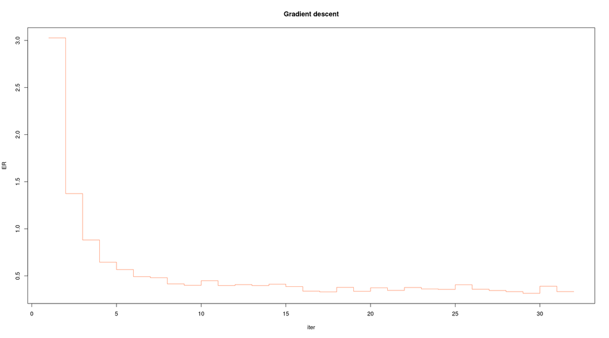

```r
result_mb <- GD_stochastic_mb(X_tr, y_tr_encoded,  gradient_linear, alpha=0.4, m=400, max_iter=1000, plot=T, verbose=100)
```

```r
pred_mb <- linear_classifier(X_te, result_mb$param)
accuracy_mb <- sum(pred_mb == y_tr_encoded) / length(y_tr_encoded)
cat(paste("Accuracy of the model:", accuracy_mb))
```

```
## Accuracy of the model: 0.501073390580831
```

```
## [1] "2021-05-31 19:34:23 CEST"
## [1] "Entering gradient loop..."
## [1] "Iteration 100  ER: 1.90028961709947"
## [1] "Iteration 200  ER: 0.2349471264641"
## [1] "Iteration 300  ER: 5.62025266055696"
## [1] "Iteration 400  ER: 1.90243332028623"
## [1] "Iteration 500  ER: 3.6352039307771"
## [1] "Iteration 600  ER: 0.000130563825283144"
## [1] "Iteration 700  ER: 10.9103619308882"
## [1] "Iteration 800  ER: 1.23456581401442"
## [1] "Iteration 900  ER: 0.219353844633166"
## [1] "Iteration 1000  ER: 4.52319645696605"
## [1] "Iteration 1100  ER: 0.35272986461817"
## [1] "Iteration 1200  ER: 0.0786633935349481"
## [1] "Iteration 1300  ER: 20.071570222043"
## [1] "Iteration 1400  ER: 9.00901370645683"
## [1] "Iteration 1500  ER: 0.159554015107015"
## [1] "Converged after 1568 iterations | ER: 0.0203617204402157"
## Time difference of 3.465119 mins
```

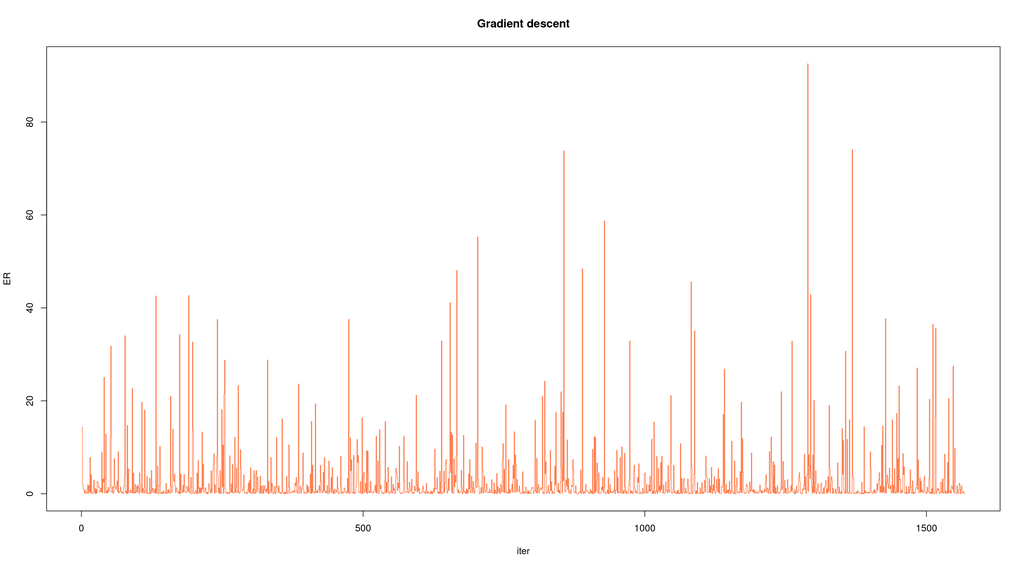

```r
result_online <- GD_stochastic_online(X_tr, y_tr_encoded, alpha=0.4, max_iter=5000,  plot=T, verbose=100)
```

```r
pred_online <- linear_classifier(X_te, result_online$param)
accuracy_online <- sum(pred_online == y_tr_encoded) / length(y_tr_encoded)
cat(paste("Accuracy of the model:", accuracy_online))
```

```
## Accuracy of the model: 0.498213238039362
```

```
## [1] "2021-05-31 19:56:55 CEST"
## [1] "Entering gradient loop..."
## [1] "Iteration 10  ER: 5.34660601458173"
## [1] "Iteration 20  ER: 3.01183394853377"
## [1] "Iteration 30  ER: 3.8830794097597"
## [1] "Iteration 40  ER: 4.58511894952188"
## [1] "Iteration 50  ER: 3.31889710538668"
## [1] "Converged after 50 iterations | ER: 2.88651682315449"
## Time difference of 7.236275 mins
```

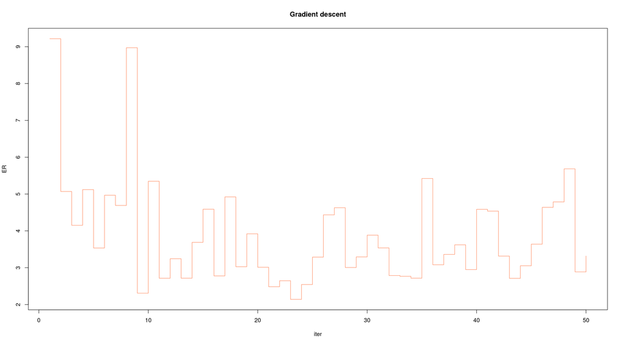

```r
result_hybrid <- GD_stochastic_hybrid(X_tr, y_tr_encoded, alpha=0.4, m=100, max_iter=50, plot=T, verbose=90)
```

```r
pred_hybrid <- linear_classifier(X_te, result_hybrid$param)
accuracy_hybrid <- sum(pred_hybrid == y_tr_encoded) / length(y_tr_encoded)
cat(paste("Accuracy of the model:", accuracy_hybrid))
```

```
## Accuracy of the model: 0.498339911461945
```